# 正多邊形、等腰等邊與角平分線綜合

> 來源整理：改國二下5_三角形的內角與外角_易讀版.md

## 正多邊形、正三角形與等腰綜合

> 學習目標：正圖形綜合題常把固定角度藏在圖形裡，要先把 60°、90°、108° 這些角找出來。

### 先抓住核心

- 正三角形每個內角是 60°。
- 正方形每個內角是 90°。
- 正五邊形每個內角是 108°。
- 等腰三角形兩底角相等；知道頂角後可用 (180° - 頂角)/2 求底角。
- 綜合題常搭配周角 360°，把一點周圍已知角扣掉。

### 解題流程

1. 先標出正圖形固定角度。
2. 找出等腰三角形，補上相等底角。
3. 若角繞同一點，使用周角 360°。
4. 必要時再用外角定理或內角和定理收尾。

### 公式、性質與判斷

- **正三角形**：每角 60°。
- **正方形**：每角 90°。
- **正五邊形**：每角 108°。
- **等腰底角**：底角 = (180° - 頂角)/2。

### 例題拆解

- 正五邊形內角 108°，扣掉正三角形的 60°，可得到 48°。
- 若等腰三角形頂角為 48°，底角是 (180° - 48°)/2 = 66°。
- 正方形內角 90° 扣掉正三角形 60°，得到 30°，再用等腰三角形求底角 75°。

### 易錯提醒

- 把正五邊形內角誤記成 120°。
- 看到兩邊相等卻忘記底角相等。

### 小練一下

- 正五邊形每個內角是多少？
- 等腰三角形頂角 40°，底角各是多少？

### 記憶鉤子

- 正圖形題先把固定角度標好，整題會亮很多。
- 等腰三角形的兩個底角，是綜合題常見的省力點。

### 圖像化理解

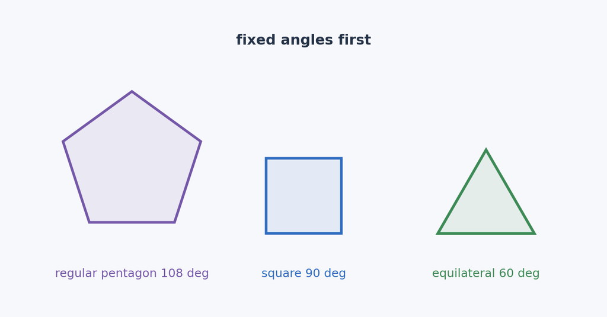

正多邊形、正三角形與等腰綜合

圖解：用正五邊形、正方形與正三角形標出常用固定角。

## 等腰三角形綜合角度

> 學習目標：等腰三角形題通常先用兩底角相等，再和內角和或外角定理合併。

### 先抓住核心

- 等腰三角形兩腰相等，兩底角也相等。
- 若知道頂角，可用 (180° - 頂角)/2 求底角。
- 若有兩個等腰三角形疊在一起，可把兩組底角設成 x、y。
- 多個三角形內角和可合併使用，例如兩個三角形內角和總共 360°。
- 最後常要用 180° 減掉 x+y 求某個外側角或夾角。

### 解題流程

1. 先找等腰三角形，標出相等底角。
2. 用三角形內角和建立 x、y 的關係。
3. 若有兩個三角形，可把兩個內角和一起看成 360°。
4. 把目標角寫成 180° - (x+y) 或外角和。

### 公式、性質與判斷

- **等腰底角**：兩底角相等。
- **兩三角形內角和**：360°。
- **常見收尾**：目標角 = 180° - (x+y)。

### 例題拆解

- 若 ∠B + ∠C = 80°，兩個等腰三角形合併後可得 x+y = 140°。
- 因此目標角可為 180° - 140° = 40°。
- 若頂角是 30°，等腰底角各是 75°。

### 易錯提醒

- 只看到圖像像等腰就使用底角相等，但題目沒有給等邊或等腰條件。
- 把頂角和底角的位置標反。

### 小練一下

- 等腰三角形頂角 50°，底角各是多少？
- 兩個三角形內角和合起來是多少？

### 記憶鉤子

- 等腰題先標相等角，式子通常就會變短。
- 兩個三角形疊圖時，可以把兩個內角和一起使用。

### 圖像化理解

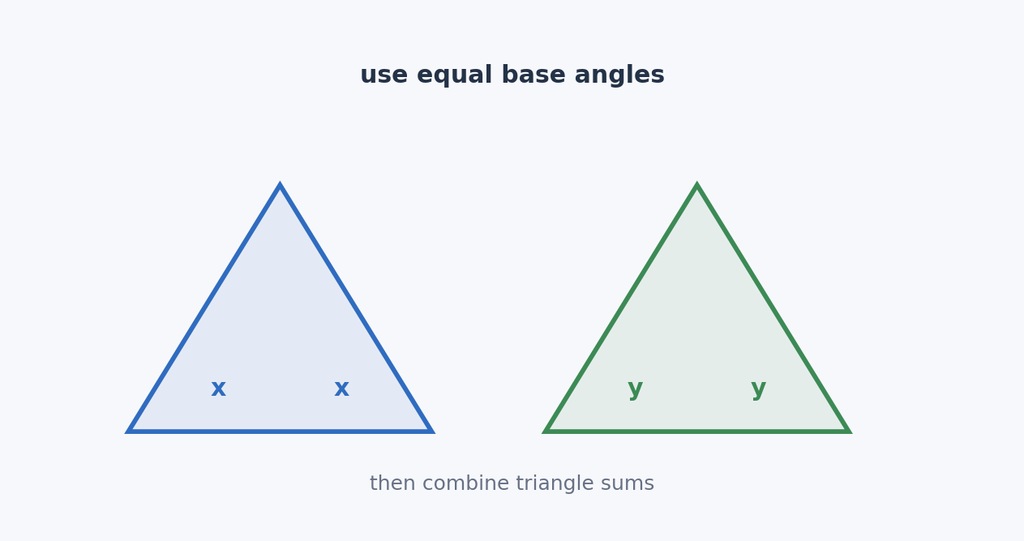

等腰三角形綜合角度

## 三角形內角平分線性質

> 學習目標：兩條內角平分線在三角形內相交時，交角和第三個角有固定關係。

### 先抓住核心

- 若 ∠B、∠C 的內角平分線交於 I，則 ∠BIC = 90° + ∠A/2。
- 因為 ∠B 與 ∠C 被各自平分，所以可把 B、C 的總和除以 2。
- 由內角和可知 ∠B + ∠C = 180° - ∠A。
- 因此半個 B 加半個 C 是 (180° - ∠A)/2。
- 再用箭頭定理或角度追蹤，可得到 ∠BIC = 90° + ∠A/2。

### 解題流程

1. 確認兩條線都是內角平分線。
2. 使用 ∠B + ∠C = 180° - ∠A。
3. 取一半得到 (∠B+∠C)/2。
4. 套公式 ∠BIC = 90° + ∠A/2。

### 公式、性質與判斷

- **內角平分線交角**：BIC = 90° + A/2。
- **例**：A=60° 時，BIC=120°。

### 例題拆解

- 若 ∠A = 60°，則 ∠BIC = 90° + 30° = 120°。
- 若 ∠A = 80°，則 ∠BIC = 90° + 40° = 130°。
- 這裡的 I 是兩條內角平分線在三角形內的交點。

### 易錯提醒

- 把內角平分線公式誤記成 90° - A/2。
- 沒有確認 I 是否在三角形內，就套錯公式。

### 小練一下

- 若 ∠A = 50°，∠BIC 是多少？
- 這個公式使用的是內角平分線還是外角平分線？

### 記憶鉤子

- 兩內角平分線交於內部：90° 加半個第三角。
- 看到 BIC 且 I 在三角形內，優先想 90° + A/2。

### 圖像化理解

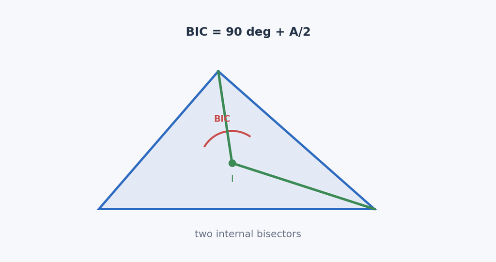

三角形內角平分線性質

圖解：標示 B、C 兩條內角平分線交於 I，並示意 ∠BIC = 90° + A/2。

## 三角形外角平分線性質

> 學習目標：兩條外角平分線在三角形外相交時，交角是 90° 減去第三角的一半。

### 先抓住核心

- 若 ∠B、∠C 的外角平分線交於三角形外一點 P，則 ∠BPC = 90° - ∠A/2。
- 外角平分線分的是外角，不是原本的內角。
- 這個交點 P 在三角形外，因此公式和內角平分線相反，是減半角。
- 若 ∠A 越大，∠BPC 會越小。
- 解題時要先確認兩條線是不是外角平分線。

### 解題流程

1. 確認 P 是兩條外角平分線交點。
2. 找出沒有被平分線夾住的第三角 A。
3. 套公式 ∠BPC = 90° - ∠A/2。
4. 代入角度並檢查結果是否小於 90°。

### 公式、性質與判斷

- **外角平分線交角**：BPC = 90° - A/2。
- **例**：A=30° 時，BPC=75°。

### 例題拆解

- 若 ∠A = 30°，則 ∠BPC = 90° - 15° = 75°。
- 若 ∠A = 60°，則 ∠BPC = 90° - 30° = 60°。
- 原講義範例中，若 x+y=105°，∠P=180°-105°=75°，也對應 A=30° 的情況。

### 易錯提醒

- 把外角平分線公式誤套成 90° + A/2。
- 把外角平分線看成內角平分線，導致交點位置判斷錯。

### 小練一下

- 若 ∠A = 40°，外角平分線交角是多少？
- 外角平分線交點通常在三角形內還是外？

### 記憶鉤子

- 兩外角平分線交於外部：90° 減半個第三角。
- 外角平分線的公式和內角平分線只差一個加減號，位置也不同。

### 圖像化理解

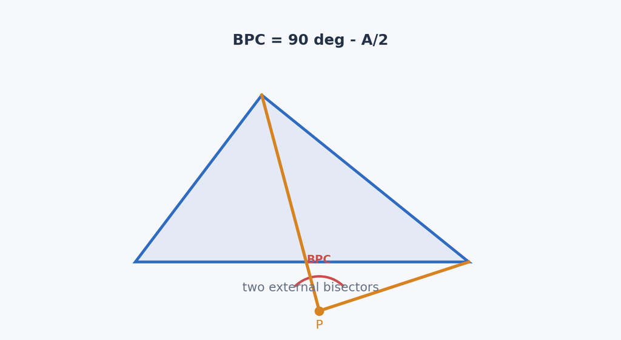

三角形外角平分線性質

圖解：用三角形外部交點 P 示意兩外角平分線的公式。

## 三角形內、外角平分線性質

> 學習目標：一條內角平分線和一條外角平分線相交時，交角等於第三角的一半。

### 先抓住核心

- 若 ∠B 的內角平分線與 ∠C 的外角平分線交於 E，則 ∠BEC = ∠A/2。
- 這個公式介於前兩個公式之間，沒有 90°。
- 推導時常用外角定理，把外角平分後的角度和內角平分後的角度相減。
- 若 ∠A = 60°，則 ∠BEC = 30°。
- 要先確認一條是內角平分線，另一條是外角平分線。

### 解題流程

1. 確認一條線平分內角，另一條線平分外角。
2. 找第三角 A。
3. 套公式 ∠BEC = ∠A/2。
4. 若題目給平分角相等標記，先判斷是內內、外外，還是內外。

### 公式、性質與判斷

- **內外角平分線交角**：BEC = A/2。
- **例**：A=60° 時，BEC=30°。

### 例題拆解

- 若 ∠A = 60°，則 ∠BEC = 30°。
- 若 ∠A = 84°，則 ∠BEC = 42°。
- 若題目標 ∠1=∠2、∠3=∠4，要先看它們分別是內角還是外角。

### 易錯提醒

- 忘記判斷平分的是內角還是外角，三個公式亂套。
- 看到角平分線就只想到除以 2，卻沒有分清楚交角是哪一種。

### 小練一下

- 若 ∠A = 70°，內外角平分線交角是多少？
- 內外角平分線公式中有沒有 90°？

### 記憶鉤子

- 一內一外：只剩半個第三角。
- 三個公式可以一起記：內內是加 90°，外外是減 90°的一半形式，內外是 A/2。

### 圖像化理解

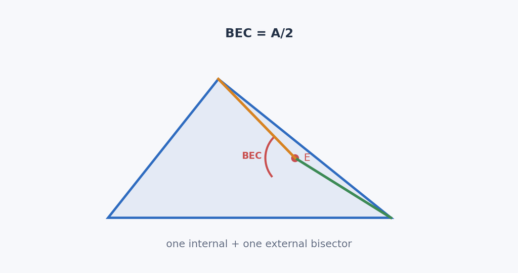

三角形內、外角平分線性質

圖解：示意一條內角平分線與一條外角平分線交於 E，得到 ∠BEC = A/2。